# Practical ML - Predict activity quality from activity monitors

Tiago Tresoldi

April 29th, 2016

# Executive Summary

Using devices such as Jawbone Up, Nike FuelBand, and Fitbit it is now possible to collect a large amount of data about personal activity relatively inexpensively. These type of devices are part of the quantified self movement – a group of enthusiasts who take measurements about themselves regularly to improve their health, to find patterns in their behavior, or because they are tech geeks. One thing that people regularly do is quantify how much of a particular activity they do, but they rarely quantify how well they do it.

In this project, we used data from accelerometers on the belt, forearm, arm, and dumbell of 6 participants which were asked to perform barbell lifts correctly and incorrectly in 5 different ways. Our goal was to predict the manner in which they did the exercise by using machine learning techniques.

# Analysis

## Data description

More information on the data us available from the website: http://groupware.les.inf.puc-rio.br/har (see the section on the Weight Lifting Exercise Dataset). For this data set, participants were asked to perform one set of 10 repetitions of the Unilateral Dumbbell Biceps Curl in 5 different fashions. Fashions are stored in the outcome variable `classe`, and are:

- exactly according to the specification (class A)
- throwing the elbows to the front (class B)
- lifting the dumbbell only halfway (class C)
- lowering the dumbbell only halfway (class D)
- throwing the hips to the front (class E)

## System configuration

We configure our R environment by loading required libraries, downloading and loading the data set (creating the directories do hold it, if needed), and setting a random set for a reproducible research.

```r
# load required libraries, installing them if needed
if (!require("caret")) {
  install.packages("caret")
  library("caret")
}

if (!require("randomForest")) {
  install.packages("randomForest")
  library("randomForest")
}

if (!require("rpart")) {
  install.packages("rpart")
  library("rpart")
}

if (!require("rpart.plot")) {
  install.packages("rpart.plot")
  library("rpart.plot")
}

# Data variables
training.url    <- 'http://d396qusza40orc.cloudfront.net/predmachlearn/pml-training.csv'
test.cases.url  <- 'http://d396qusza40orc.cloudfront.net/predmachlearn/pml-testing.csv'
training.file   <- './data/pml-training.csv'
test.cases.file <- './data/pml-testing.csv'

# Create directories to hold data, if needed
if (!file.exists("data")) {
  dir.create("data")
}
if (!file.exists("data/submission")) {
  dir.create("data/submission")
}

# Download data
download.file(training.url, training.file)
download.file(test.cases.url,test.cases.file )

# Set seed for reproducibility
set.seed(1234)
```

## Data processing

We first process the downloaded data, removing `NA` data and columns which are irrelevant to the machine learning algorithms (descriptive values) from both the training and test sets.

```r
# load data, removing NAs
training <- read.csv(training.file, na.strings=c("NA","#DIV/0!", ""))
testing  <- read.csv(test.cases.file , na.strings=c("NA", "#DIV/0!", ""))

# removes empties
training <- training[,colSums(is.na(training)) == 0]
testing  <- testing[,colSums(is.na(testing)) == 0]

# remove useless columns
training <- training[,-c(1:7)]
testing  <- testing[,-c(1:7)]
```

We then partition the training data into training (75%) and testing (25%) categories, for performing cross-validation.

```r
subsamples  <- createDataPartition(y=training$classe, p=0.75, list=FALSE)
training.sub <- training[subsamples,]
testing.sub  <- training[-subsamples,]
```

## Exploratory analysis

We perform an initial exploratory analysis with a descriptive statistical summary of the training sub-sample, as we should not verify the data reserved for testing an cross-validation in order not to guide our methods and achieve an overfitting method.

```r
summary(training.sub)
```

```
##    roll_belt        pitch_belt          yaw_belt       total_accel_belt
##  Min.   :-28.80   Min.   :-55.8000   Min.   :-180.00   Min.   : 0.00
##  1st Qu.:  1.09   1st Qu.:  1.7100   1st Qu.: -88.30   1st Qu.: 3.00
##  Median :114.00   Median :  5.2300   Median : -12.65   Median :17.00
##  Mean   : 64.58   Mean   :  0.1437   Mean   : -10.66   Mean   :11.33
##  3rd Qu.:123.00   3rd Qu.: 14.6000   3rd Qu.:  14.10   3rd Qu.:18.00
##  Max.   :162.00   Max.   : 60.3000   Max.   : 179.00   Max.   :29.00
##   gyros_belt_x        gyros_belt_y       gyros_belt_z
##  Min.   :-1.040000   Min.   :-0.64000   Min.   :-1.4600
##  1st Qu.:-0.030000   1st Qu.: 0.00000   1st Qu.:-0.2000
##  Median : 0.030000   Median : 0.02000   Median :-0.1000
##  Mean   :-0.005533   Mean   : 0.04002   Mean   :-0.1293
##  3rd Qu.: 0.110000   3rd Qu.: 0.11000   3rd Qu.:-0.0200
##  Max.   : 2.220000   Max.   : 0.64000   Max.   : 1.6200
##   accel_belt_x      accel_belt_y     accel_belt_z     magnet_belt_x
##  Min.   :-81.000   Min.   :-69.00   Min.   :-275.00   Min.   :-52.00
##  1st Qu.:-21.000   1st Qu.:  3.00   1st Qu.:-162.00   1st Qu.:  9.00
##  Median :-14.000   Median : 35.00   Median :-153.00   Median : 35.00
##  Mean   : -5.403   Mean   : 30.15   Mean   : -72.81   Mean   : 55.94
##  3rd Qu.: -5.000   3rd Qu.: 61.00   3rd Qu.:  27.75   3rd Qu.: 60.00
##  Max.   : 85.000   Max.   :121.00   Max.   : 105.00   Max.   :485.00
##  magnet_belt_y   magnet_belt_z       roll_arm         pitch_arm
##  Min.   :354.0   Min.   :-623.0   Min.   :-180.00   Min.   :-88.200
##  1st Qu.:581.0   1st Qu.:-375.0   1st Qu.: -31.40   1st Qu.:-25.800
##  Median :601.0   Median :-320.0   Median :   0.00   Median :  0.000
##  Mean   :593.7   Mean   :-345.7   Mean   :  18.08   Mean   : -4.495
##  3rd Qu.:610.0   3rd Qu.:-306.0   3rd Qu.:  77.30   3rd Qu.: 11.400
##  Max.   :673.0   Max.   : 289.0   Max.   : 180.00   Max.   : 88.500
##     yaw_arm          total_accel_arm  gyros_arm_x        gyros_arm_y
##  Min.   :-180.0000   Min.   : 1.00   Min.   :-6.37000   Min.   :-3.4400
##  1st Qu.: -43.3000   1st Qu.:17.00   1st Qu.:-1.34500   1st Qu.:-0.8000
##  Median :   0.0000   Median :27.00   Median : 0.08000   Median :-0.2400
##  Mean   :  -0.7604   Mean   :25.52   Mean   : 0.04276   Mean   :-0.2557
##  3rd Qu.:  45.9000   3rd Qu.:33.00   3rd Qu.: 1.57000   3rd Qu.: 0.1400
##  Max.   : 180.0000   Max.   :66.00   Max.   : 4.87000   Max.   : 2.8400
##   gyros_arm_z       accel_arm_x       accel_arm_y       accel_arm_z
##  Min.   :-2.3300   Min.   :-404.00   Min.   :-318.00   Min.   :-636.00
##  1st Qu.:-0.0700   1st Qu.:-241.00   1st Qu.: -54.00   1st Qu.:-142.00
##  Median : 0.2300   Median : -43.00   Median :  12.50   Median : -46.00
##  Mean   : 0.2713   Mean   : -59.72   Mean   :  32.35   Mean   : -71.25
```

[output cut: 50 more lines]

```
##  Max.   :311.00000   Max.   :231.0000   Max.   : 477.00   Max.   : 923
##  accel_forearm_z   magnet_forearm_x  magnet_forearm_y magnet_forearm_z
##  Min.   :-446.00   Min.   :-1280.0   Min.   :-896.0   Min.   :-973.0
##  1st Qu.:-181.00   1st Qu.: -616.0   1st Qu.:  -1.0   1st Qu.: 183.0
##  Median : -38.00   Median : -378.0   Median : 589.0   Median : 511.0
##  Mean   : -54.48   Mean   : -311.6   Mean   : 378.5   Mean   : 392.8
##  3rd Qu.:  27.00   3rd Qu.:  -72.0   3rd Qu.: 736.0   3rd Qu.: 653.0
##  Max.   : 291.00   Max.   :  672.0   Max.   :1480.0   Max.   :1090.0
##  classe
##  A:4185
##  B:2848
##  C:2567
##  D:2412
##  E:2706
##
```

We also perform an investigation of the `classe` variable (the outcome), which suggests `D` (lowering the dumbbell only halfway) as the least frequent level and `A` (exactly according to the specification) as the most common.

```r
table(training.sub$classe)
```

```
##
##    A    B    C    D    E
## 4185 2848 2567 2412 2706
```

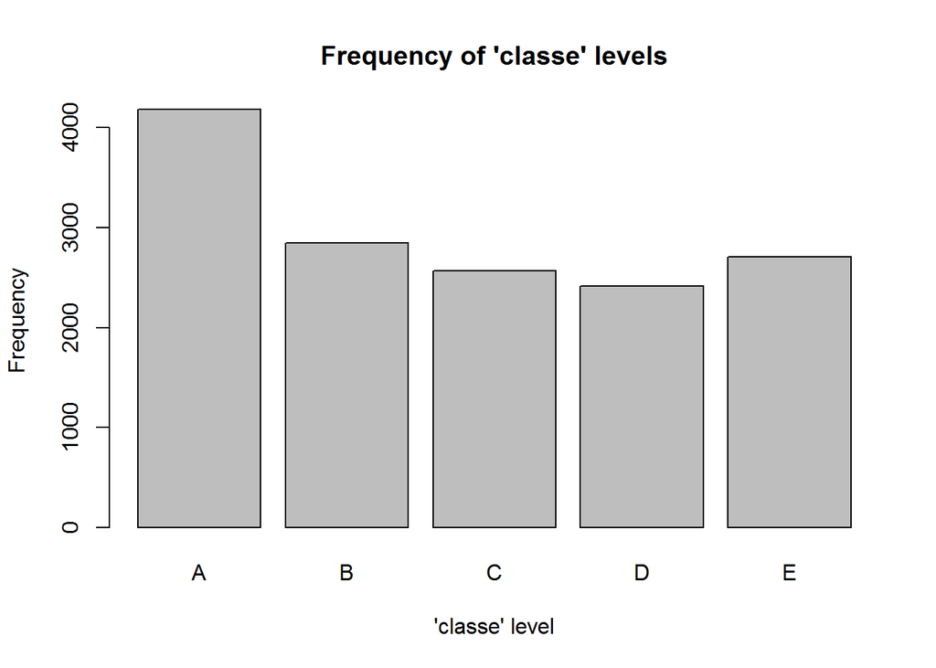

```r
plot(training.sub$classe, main="Frequency of 'classe' levels", xlab="'classe' level", ylab="Frequency")
```

## Prediction models

In this section, we apply two different machine learning methods to generate models for prediction, testing the results while verifying how each model performs on the cross validation set that we held out from training.

### Decision tree

We build a first model using recursive partitioning and regression trees, printing and plotting it. The first node division is related to the variable `roll_belt` being less than 130.5.

```r
# fit model
rpart.model <- rpart(classe ~ ., data=training.sub, method="class")

# print the model
rpart.model
```

```
## n= 14718
##
## node), split, n, loss, yval, (yprob)
##       * denotes terminal node
##
##     1) root 14718 10533 A (0.28 0.19 0.17 0.16 0.18)
##       2) roll_belt< 130.5 13483  9308 A (0.31 0.21 0.19 0.18 0.11)
##         4) pitch_forearm< -34.35 1163     4 A (1 0.0034 0 0 0) *
##         5) pitch_forearm>=-34.35 12320  9304 A (0.24 0.23 0.21 0.2 0.12)
##          10) magnet_dumbbell_y< 439.5 10462  7499 A (0.28 0.18 0.24 0.19 0.11)
##            20) roll_forearm< 123.5 6480  3837 A (0.41 0.18 0.18 0.17 0.06)
##              40) magnet_dumbbell_z< -25.5 2237   745 A (0.67 0.2 0.019 0.081 0.031)
##                80) roll_forearm>=-136.5 1859   401 A (0.78 0.16 0.02 0.028 0.0043) *
##                81) roll_forearm< -136.5 378   228 B (0.09 0.4 0.011 0.34 0.16) *
##              41) magnet_dumbbell_z>=-25.5 4243  3092 A (0.27 0.17 0.27 0.21 0.076)
##                82) yaw_belt>=168.5 577    89 A (0.85 0.087 0 0.062 0.0052) *
##                83) yaw_belt< 168.5 3666  2537 C (0.18 0.19 0.31 0.24 0.087)
##                 166) accel_dumbbell_y>=-40.5 3160  2303 D (0.21 0.21 0.22 0.27 0.094)
##                   332) pitch_belt< -42.85 382    68 B (0.026 0.82 0.1 0.026 0.024) *
##                   333) pitch_belt>=-42.85 2778  1931 D (0.23 0.12 0.23 0.3 0.1)
##                     666) roll_belt>=125.5 652   261 C (0.37 0.017 0.6 0.014 0.0046)
##                      1332) magnet_belt_z< -323.5 209     6 A (0.97 0 0.014 0 0.014) *
##                      1333) magnet_belt_z>=-323.5 443    55 C (0.079 0.025 0.88 0.02 0) *
##                     667) roll_belt< 125.5 2126  1288 D (0.19 0.16 0.12 0.39 0.13)
##                      1334) pitch_belt>=1.04 1344  1028 B (0.23 0.24 0.13 0.22 0.19)
##                        2668) accel_dumbbell_z< 27.5 846   555 A (0.34 0.15 0.2 0.27 0.035)
##                          5336) yaw_forearm>=-94.65 618   327 A (0.47 0.19 0.22 0.078 0.037)
##                           10672) magnet_forearm_z>=-68.5 382   102 A (0.73 0.14 0.013 0.1 0.016) *
##                           10673) magnet_forearm_z< -68.5 236   104 C (0.047 0.28 0.56 0.038 0.072) *
##                          5337) yaw_forearm< -94.65 228    51 D (0 0.039 0.15 0.78 0.031) *
##                        2669) accel_dumbbell_z>=27.5 498   274 E (0.034 0.38 0.006 0.13 0.45)
##                          5338) roll_dumbbell< 53.36059 310   139 B (0.052 0.55 0.0097 0.19 0.2) *
##                          5339) roll_dumbbell>=53.36059 188    25 E (0.0053 0.09 0 0.037 0.87) *
##                      1335) pitch_belt< 1.04 782   235 D (0.13 0.019 0.11 0.7 0.041) *
##                 167) accel_dumbbell_y< -40.5 506    68 C (0.0099 0.047 0.87 0.038 0.04) *
##            21) roll_forearm>=123.5 3982  2663 C (0.08 0.18 0.33 0.22 0.18)
##              42) magnet_dumbbell_y< 291.5 2330  1199 C (0.096 0.13 0.49 0.15 0.14)
##                84) magnet_forearm_z< -251 187    36 A (0.81 0.08 0 0.037 0.075) *
##                85) magnet_forearm_z>=-251 2143  1012 C (0.034 0.14 0.53 0.16 0.15) *
##              43) magnet_dumbbell_y>=291.5 1652  1101 D (0.058 0.25 0.11 0.33 0.25)
##                86) accel_forearm_x>=-101.5 1070   708 E (0.052 0.31 0.16 0.14 0.34)
##                 172) magnet_arm_y>=188.5 456   208 B (0.018 0.54 0.24 0.096 0.11) *
##                 173) magnet_arm_y< 188.5 614   300 E (0.078 0.14 0.1 0.17 0.51) *
##                87) accel_forearm_x< -101.5 582   177 D (0.069 0.13 0.029 0.7 0.079) *
##          11) magnet_dumbbell_y>=439.5 1858   912 B (0.029 0.51 0.041 0.23 0.19)
##            22) total_accel_dumbbell>=5.5 1315   452 B (0.04 0.66 0.057 0.022 0.22)
##              44) roll_belt>=-0.58 1109   246 B (0.048 0.78 0.068 0.026 0.08) *
##              45) roll_belt< -0.58 206     0 E (0 0 0 0 1) *
##            23) total_accel_dumbbell< 5.5 543   145 D (0 0.15 0.0037 0.73 0.11) *
##       3) roll_belt>=130.5 1235    10 E (0.0081 0 0 0 0.99) *
```

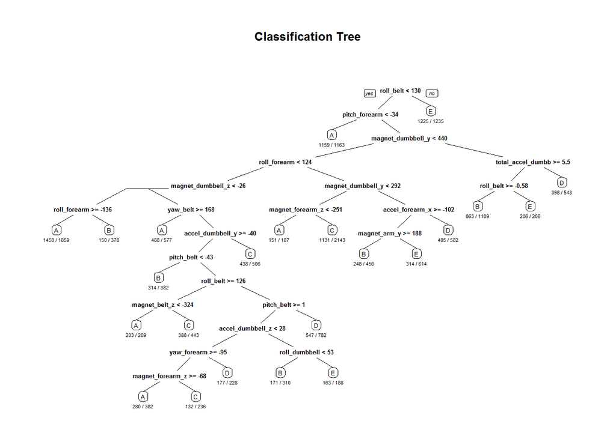

```r
# plot the result
rpart.plot(rpart.model, main="Classification Tree", extra=2, under=TRUE, faclen=0)
```

We predict outcome values on the `testing.sub` data to evaluate the model, analyzing the results with a confusion matrix. As an overall statistic, the accuracy of our model is found to be 0.74.

```r
# predict values
rpart.predict <- predict(rpart.model, testing.sub, type = "class")

# print confustion matrix
confusionMatrix(rpart.predict, testing.sub$classe)
```

```
## Confusion Matrix and Statistics
##
##           Reference
## Prediction    A    B    C    D    E
##          A 1235  157   16   50   20
##          B   55  568   73   80  102
##          C   44  125  690  118  116
##          D   41   64   50  508   38
##          E   20   35   26   48  625
##
## Overall Statistics
##
##                Accuracy : 0.7394
##                  95% CI : (0.7269, 0.7516)
##     No Information Rate : 0.2845
##     P-Value [Acc > NIR] : < 2.2e-16
##
##                   Kappa : 0.6697
##  Mcnemar's Test P-Value : < 2.2e-16
##
## Statistics by Class:
##
##                      Class: A Class: B Class: C Class: D Class: E
## Sensitivity            0.8853   0.5985   0.8070   0.6318   0.6937
## Specificity            0.9307   0.9216   0.9005   0.9529   0.9678
## Pos Pred Value         0.8356   0.6469   0.6313   0.7247   0.8289
## Neg Pred Value         0.9533   0.9054   0.9567   0.9296   0.9335
## Prevalence             0.2845   0.1935   0.1743   0.1639   0.1837
## Detection Rate         0.2518   0.1158   0.1407   0.1036   0.1274
## Detection Prevalence   0.3014   0.1790   0.2229   0.1429   0.1538
## Balanced Accuracy      0.9080   0.7601   0.8537   0.7924   0.8307
```

### Random forest

We build a second model using random forest, printing and plotting it. The model used 500 trees and the plot shows that at about 100 the model has already achieved the best possible performance.

```r
# fit model
rf.model <- randomForest(classe ~ ., data=training.sub, method="class")

# print the model
rf.model
```

```
##
## Call:
##  randomForest(formula = classe ~ ., data = training.sub, method = "class")
##                Type of random forest: classification
##                      Number of trees: 500
## No. of variables tried at each split: 7
##
##         OOB estimate of  error rate: 0.43%
## Confusion matrix:
##      A    B    C    D    E  class.error
## A 4182    2    0    0    1 0.0007168459
## B   14 2830    4    0    0 0.0063202247
## C    0   11 2553    3    0 0.0054538372
## D    0    0   18 2392    2 0.0082918740
## E    0    1    3    5 2697 0.0033259424
```

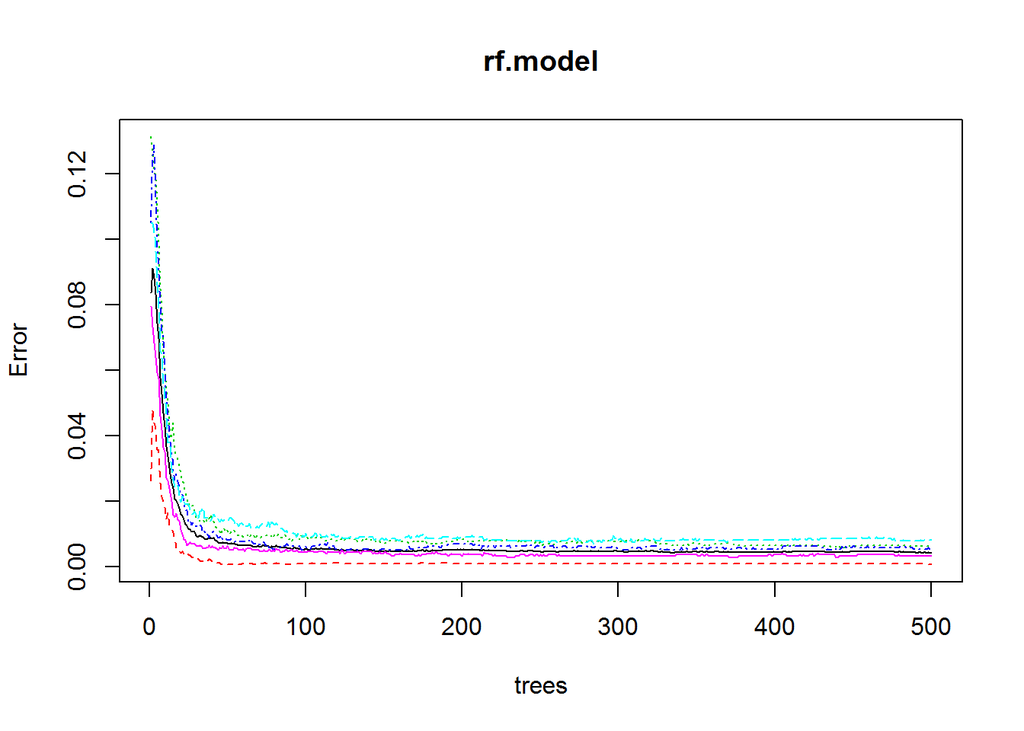

```r
plot(rf.model)
```

Once more, we predict outcome values on the `testing.sub` data to evaluate the model, analyzing the results with a confusion matrix. As an overall statistic, the accuracy of this model is found to be of 0.99, far better than the previous one and with no expected improvement.

```r
# predicti values
rf.predict <- predict(rf.model, testing.sub, type = "class")

# print confustion matrix
confusionMatrix(rf.predict, testing.sub$classe)
```

```
## Confusion Matrix and Statistics
##
##           Reference
## Prediction    A    B    C    D    E
##          A 1394    3    0    0    0
##          B    1  944   10    0    0
##          C    0    2  843    6    0
##          D    0    0    2  798    0
##          E    0    0    0    0  901
##
## Overall Statistics
##
##                Accuracy : 0.9951
##                  95% CI : (0.9927, 0.9969)
##     No Information Rate : 0.2845
##     P-Value [Acc > NIR] : < 2.2e-16
##
##                   Kappa : 0.9938
##  Mcnemar's Test P-Value : NA
##
## Statistics by Class:
##
##                      Class: A Class: B Class: C Class: D Class: E
## Sensitivity            0.9993   0.9947   0.9860   0.9925   1.0000
## Specificity            0.9991   0.9972   0.9980   0.9995   1.0000
## Pos Pred Value         0.9979   0.9885   0.9906   0.9975   1.0000
## Neg Pred Value         0.9997   0.9987   0.9970   0.9985   1.0000
## Prevalence             0.2845   0.1935   0.1743   0.1639   0.1837
## Detection Rate         0.2843   0.1925   0.1719   0.1627   0.1837
## Detection Prevalence   0.2849   0.1947   0.1735   0.1631   0.1837
## Balanced Accuracy      0.9992   0.9960   0.9920   0.9960   1.0000
```

## Conclusions

### Result

The Random Forest algorithm performed far better than the Decision Tree one, and as there seems to be no room for improvement is chosen without further model exploration. The expected out-of-sample error is estimated at 0.5%.

# Submission

The code below generates the data for project submission using the best model of the above analysis, i.e., the random forest model.

```r
# predict values
predicted.values <- predict(rf.model, testing, type="class")

# print predicted values
predicted.values
```

```
##  1  2  3  4  5  6  7  8  9 10 11 12 13 14 15 16 17 18 19 20
##  B  A  B  A  A  E  D  B  A  A  B  C  B  A  E  E  A  B  B  B
## Levels: A B C D E
```

```r
# output

pml_write_files = function(x){
  for (i in 1:length(x)){
    filename = paste0("./data/submission/problem_id_",i,".txt")
    write.table(x[i], file=filename, quote=FALSE, row.names=FALSE, col.names=FALSE)
  }
}

pml_write_files(predicted.values)
```